# econ2200Ch07 slides

## ECON2200H

### Introduction to Statistics for Economics and Management

### 2020 Winter Term

### Week 06: Sampling and Sampling Distributions

#### 10 February 2020

### Reading: Chapter 7 of textbook.

## Outline

- Law of large numbers
- Central limit theorems
- Sampling method
- Sampling distribution

## 0. From probability to statistics

- Probability theory studies the distribution of random variables with known parameters,
  - i.e., we know the probability functions and we know the parameter values.
- In statistics, one applies some techniques to a **sample** of data to "guess" the probability function and to estimate its parameters.
- Sample surveys are used to obtain information about a large population by examining a small fraction of that population.
- For example, Statistics Canada conducts hundreds of surveys, including the census survey.

## 1. The Law of Large Numbers

- A **random sample** from a distribution $f$ consists of $n$ independent random variables $X_1, \cdots, X_n$, where these random variables are independently and identically distributed. That is, $X_i$ has the same distribution $f$ for all $i$.
- The **sample mean** of a random sample of size $n$ is $\overline{X}_n = \frac{1}{n}(X_1+\cdots+X_n)$.
- The mean of the sample mean is $E[\overline{X}_n] = \mu$ and the variance of the sample mean is $\text{var}(\overline{X}_n) = \sigma^2 / n$.
- The **law of large numbers**. Let $X_1, X_2, \cdots, X_i, \cdots$ be a sequence of independent random variables with $E[X_i] = \mu$ and $\text{var}(X_i) = \sigma^2$ for all $i$. Let $\overline{X}_n = \frac{1}{n}(X_1+\cdots+X_n)$. Then, for any $\varepsilon > 0$, $$P(|\overline{X}_n -\mu|>\varepsilon)\rightarrow 0 \text{ as } n \rightarrow \infty.$$
- Loosing speaking, as $n\rightarrow \infty$, $\overline{X}_n$ approaches to $\mu$.

## 2. The Central Limit Theorem

- The most important theorem in probability and statistics.
- **Central limit theorem**: Let $X_1, X_2, \cdots, X_n$ be a sequence of independent random variables. These random variables all have the same distribution with mean $\mu$ and variance $\sigma^2$. Define $S_n = X_1+X_2+\cdots+X_n$. For any real numbers $a$ and $b$, $$\lim_{n \rightarrow \infty} P\left( a \le \frac{S_n - n \mu}{\sigma \sqrt{n}} \le b \right) = \Phi(b) - \Phi(a),$$ where $\Phi(x)$ is the standard normal cumulative distribution function.
- $\Phi(b) - \Phi(a)$ is the probability of $a \le \frac{S_n - n \mu}{\sigma \sqrt{n}} \le b $, the area under the graph of standard normal density function $\phi(x)$.
- **Interpretation**: If $X_1, X_2,\cdots,X_n$ are independent random variables each having the same distribution with mean $\mu$ and variance $\sigma^2$, then the standardized random variable $\frac{S_n-n \mu}{\sigma \sqrt{n}}$ has an approximately the standard normal distribution (with mean $0$ and variance $1$), when $n$ is sufficiently large.
- **Interpretation**: In terms of averaging random variables, the central limit theorem says this: If $X_1, X_2,\cdots,X_n$ are independent random variables each having the same distribution with mean $\mu$ and variance $\sigma^2$, then $\overline{X}_n = \frac{1}{n}(X_1+X_2+\cdots+X_n)$ approximately has a normal distribution with mean $\mu$ and variance $\sigma^2/n$ when $n$ is sufficiently large.
- **Central limit theorem holds no matter what the distribution of random variables $X_1,X_2,\cdots$ take. As long as these random variables are independent and all have the same distribution, their sum and average both have a normal distribution.**
- **Example**. Suppose that each of $X_1,X_2,\cdots,X_n$ has a uniform distribution on [0,1]. We knew that the mean of $X_k$ is $\frac{1}{2}$ and the variance is $\frac{1}{12}$.
- The sum of $n=12$ such uniform random variables, $S_{12} = X_1+X_2+\cdots+X_{12}$, has mean 6 and variance 1. The distribution of $S_{12}$ is fairly close to a normal distribution.
- Random variable $X$ with binomial distribution with $n=100$ and $p=0.5$, the distribution is fairly close to a normal distribution $N(50, 25)$.
- Recall $X$ can be considered as $X= X_1+X_2+\cdots+X_n$ where $X_k$ each has a Bernoulli distribution with parameter $p$. $X$ is the sum of independent random variables $X_i$'s each having the same distribution, thus central limit theorem applies.

[figure not shown]

## 3. Sampling

- Sample surveys are used to obtain information regarding a large population
- Recall in Chapters 2 and 3, we calculated moments (mean, variance, etc.) for both population and samples.
- Techniques of sampling
  - Simple random sampling
  - Systematic random sampling
  - Stratified random sampling
  - Cluster sampling

### Sampling techniques

- **Simple random sampling**: Each particular sample of size $n$ has the same probability of occurrence. The actual composition of the sample is determined by random number generators on computer.
- **Systematic random sampling**: Select a random starting point, then select sample with a pattern (say every $k$th member of a population).
- **Stratified random sampling**: The population is partitioned into subpopulations, called **strata**. A random sample is then selected from each stratum. The results from the strata are then combined to estimate population parameters.
- **Cluster sampling**: The population is divided into **clusters** using naturally occurring geographic or other boundaries. A random sample is collected by randomly selecting from each cluster.

## 4. Sampling distribution

- Consider a population of size $N$, and a random sample of size $n$ drawn from the population, Random variables $X_1, X_2, \cdots, X_n$ form a random sample.
- In a random sample, $X_i$'s are independent of each other, and all have the same distribution with mean $\mu$ and variance $\sigma^2$.
- Must be aware that each $X_i$ is a *random variable*. $X_i$ is not the same as $x_i$: $X_i$ is the value of the $i$th member of the sample, which is random; $x_i$ is the value of the $i$th member of the population, which is fixed.
- Illustrate the above bullet with an example.
- **Population parameters** characterize population distribution, e.g. $\mu$ and $\sigma$.
- **Population mean** is computed as $$\mu = \frac{1}{N} (x_1+x_2+\cdots+x_N).$$
- **Sample mean** is defined as $$\overline{X}_n = \frac{1}{n} (X_1+X_2+\cdots+X_n).$$
- **Population variance** is computed as $$\sigma^2 = \frac{1}{N}[(x_1-\mu)^2+(x_2-\mu)^2+\cdots+(x_N-\mu)^2],$$ or equivalently, $$\sigma^2 = \frac{1}{N}(x_1^2 + x_2^2+\cdots+x_N^2) - \mu^2.$$
- **Sample variance** is defined as $$s^2 = \frac{1}{n-1}[(X_1-\overline{X}_n)^2+(X_2-\overline{X}_n)^2+\cdots+(X_n-\overline{X}_n)^2],$$ or equivalently, $$s^2 = \frac{1}{n-1}(X_1^2 + X_2+\cdots+X_n^2) - \frac{n}{n-1}\overline{X}_n^2.$$
- Since each $X_i$ is a random variable, so is the sample mean $\overline{X}_n$. Then $\overline{X}_n$ has a probability distribution, just like any random variable.
- The probability distribution of $\overline{X}_n$ is called **sampling distribution** of $\overline{X}_n$.
- **In general, any numeric value, or statistic, computed from a random sample is a random variable and has an associated sampling distribution**.
- We focus on the sampling distribution of statistics computed from random samples obtained by the simple random sampling.

### 4-1. The sampling distribution of $\overline{X}_n$

- We can show that $E[\overline{X}_n] = \mu$. Why? By the definition of random sample, we knew that $E[X_i]=\mu$ for each $i$ in $n$. Then, $E[\overline{X}_n] = \frac{1}{n}(E[X_1]+ E[X_2]+\cdots+E[X_n]) = \mu$.
- $E[\overline{X}_n] = \mu$ implies that the sampling distribution of $\overline{X}_n$ is centered at $\mu$.
- We can also obtain the **variance of the sample mean**. Since $\overline{X}_n$ is a random variable, we have $$\text{var}(\overline{X}_n) = \frac{1}{n^2}\left[\text{var}(X_1)+\text{var}(X_2)+\cdots+\text{var}(X_n)\right] = \frac{\sigma^2}{n}.$$
- Or, the standard deviation of $\overline{X}_n$ is $\sigma_{\overline{X}} = \frac{\sigma}{\sqrt{n}}$, which is more often called the **standard error** of the sample mean.
- (Optional to be aware of): theoretically, the above standard error corresponds to simple random sample obtained by sampling *with replacement*. Empirically, it holds **if $n$ is sufficiently large, but still smaller than $N$**.
- By the central limit theorem, as the random sample size is large ($n$ is large), the sample mean $\overline{X}_n$ has a normal distribution with mean $\mu$ and variance $\sigma^2/n$.
- We can make a $Z$-transformation of $\overline{X}_n$: $Z = \frac{\overline{X}_n - \mu}{\sigma_{\overline{X}}}$.
- The random variable $Z$ has (approximately) the standard normal distribution.

#### Example: sampling distribution of labor earnings

- Population is labor earnings of seven employees. $N=7$, population mean earnings is \$9.29.

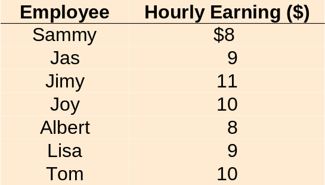

- Random sample size is $n=2$. Population size is $N=7$. There are $C_{N,n} = C_{7,2} = 21$ possible sets of values for a random sample of size 2.

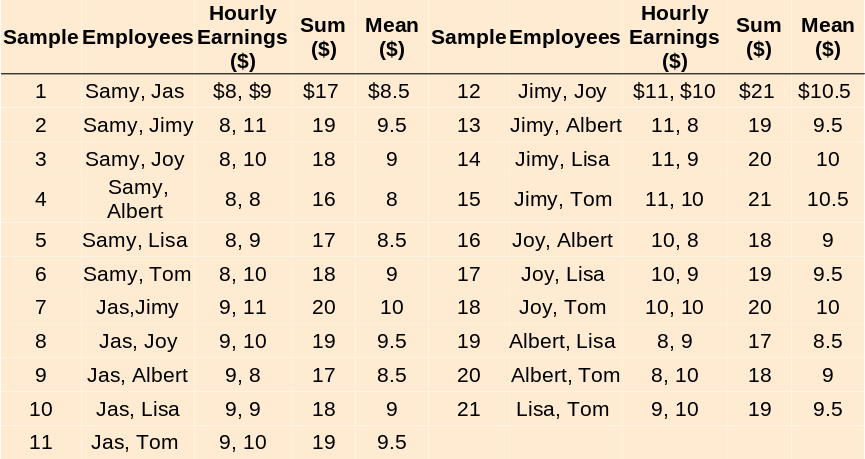

- Sampling distribution of the sample mean

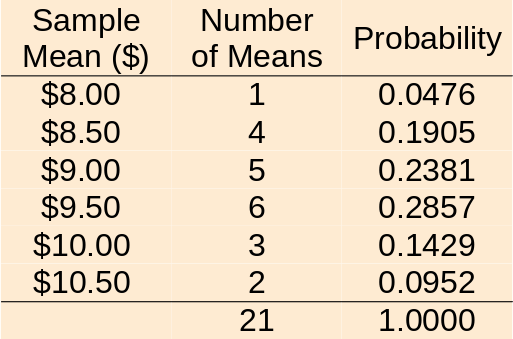

- The mean of the sample mean equals $(8.0 \cdot 0.0476+8.5 \cdot 0.1905+\cdots) = 9.29$.

[figure not shown]

### 4-2. Sampling distribution of the sample proportion

- **Proportion** is the fraction of population that has certain properties or traits.
  - e.g., in University ABC, 80 percent of its graduates enter the job market in a position related to their field of study.
  - e.g., 50 percent of population are male.
- We use $p$ to denote the population proportion.
- In a random sample of size $n$, suppose that there are $K$ observations satisfying certain properties (i.e., whether job is related to field of study, whether the individual in the sample is male.)
- The **sample proportion** is calculated as $\overline{p} = \frac{K}{n}$.
  - The sample proportion is a random variable, because $K$ is random.
- The expected value of $\overline{p}$ is $E[\overline{p}] = p$.
- The standard error (standard deviation) of the sample proportion is $\sigma_{\overline{p}} = \sqrt{\frac{p(1-p)}{n}}$
- Approximately, $\overline{p}$ has a normal distribution with mean $p$ and variance $(\sigma_{\overline{p}})^2$.
- Then $Z = \frac{\overline{p} - p}{\sigma_{\overline{p}}}$ has (approximately) the standard normal distribution, by the central limit theorem.

### 4-3. Remarks

- We only characterized the mathematical properties of statistics computed from random samples.
- These properties are: sampling distribution, expected value, variance.
- But, in the case of $\overline{X}_n$, we do not know the values of $\mu$ and $\sigma$, and in the case of $\overline{p}$, we do not know the value of $p$.
- $\mu$, $\sigma$, and $p$ are parameters characterizing the sampling distributions. For mathematical properties, we do not need to know their values.
- Their values are to be **estimated**, the main purpose and interest of statistics.